# Introduction to Text Analysis and Sentiment

Social and Cultural Analytics (7AAVBCS5)

Dr Mark J. Hill · mark.j.hill@kcl.ac.uk

23 November 2026

## Lecture Plan

- **Part I: Introduction to NLP**
- **Part II: The NLP pipeline**
- **Part III: Counting words**
- **Part IV: Sentiment in reviews**
- **Part V: Contextual Analytics**
- **Conclusion: Workshop and reporting**

**By the end of the lecture, you should be able to:**

- Explain the stages and choices in an NLP pipeline
- Distinguish corpora, documents, tokens, types and lemmas
- Use a loop to inspect tokens and choose words to count
- Create word-frequency tables for a corpus, an article and a category
- Compare word percentages across categories
- Check sentiment scores against ratings and report preprocessing decisions

# Part I: Introduction to Natural Language Processing

## What is Natural Language Processing?

The use of computational techniques to analyse natural language (written and spoken) at scale.

**Natural:** language as people express it. E.g., speeches, social media posts, literature, song lyrics, video game dialogue, etc..

**Computational:** language becomes digital representations that let us assess *relationships* between words.

**Scale:** analyse patterns across collections beyond what one person can read. While NLP can help us examine a single document, its power comes when we apply it to very large datasets.

**Related**

- Digital / computational humanities
- Text mining / language technology
- Computational linguistics
- Distant reading
- Quantitative text analysis
- **Large language models**

## The scale problem

**The challenge:** mass digitisation of library and archive material, alongside ever-growing born-digital text: the web, social media and user-generated content.

**The result:** textual collections too large for a person to read in full.

**The opportunity:** explore, compare and find patterns across those collections.

**New reserach questions:** Questions we can investigate

How has vocabulary changed over time?

What topics recur across social media posts?

How do different authors use language?

What themes connect a collection of texts?

How do evaluations differ between writers?

Which words collocate with an idea or concept?

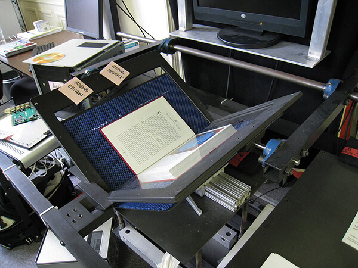

Internet Archive scanner

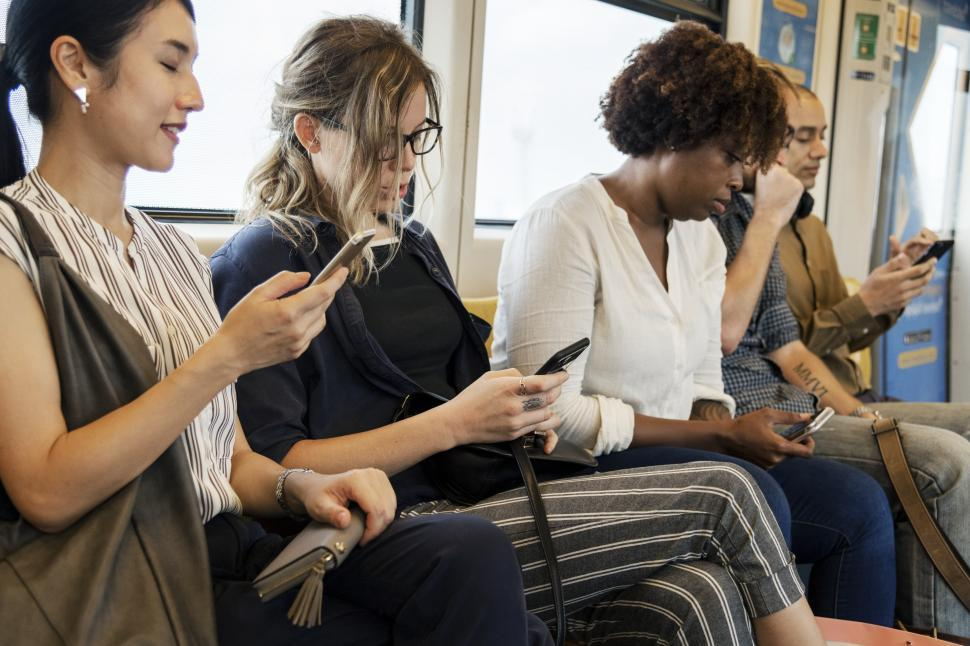

## Today’s questions

**How are London’s cultural venues described?**

What data? Wikipedia articles that cover the venues we’ve been looking at.

**How do visitors evaluate a museum experience?**

What data? Visitor reviews.

We already know how to count venue records. Now we will look at text to investigate how those venues are described: their histories, activities, and public evaluations.

# Part II: The NLP pipeline

## A typical NLP pipeline

1. Tokenisation
2. Pre-processing
3. Lemmatisation
4. Morphological tagging
5. Part-of-speech tagging
6. Syntactic parsing
7. Information extraction
8. Analysis

The process through which text becomes **countable** units and analytical outputs.

Not every step necessary. Choose the operations needed for the question. These are not compulsory steps.

## Introducing spaCy I

**spaCy is a Python library for working with human language.** It identifies words and punctuation, and supplies information about them for text analysis.

spaCy provides the tools. We also load an **English language package** containing language rules and models trained on example texts. We can use these without training a model ourselves.

Live notebook **01** · Introducing spaCy

```python
import spacy
nlp = spacy.load("en_core_web_sm")
weather_text = ("This morning there were clouds in the sky. However, the weather improved in the afternoon!")
weather_doc = nlp(weather_text)
print(type(weather_text))
print(type(weather_doc))
print(len(weather_doc))
```

```
<class 'str'>
<class 'spacy.tokens.doc.Doc'>
18
```

`import spacy` makes the library available. `spacy.load("en_core_web_sm")` loads an installed English package: `en` = English, `core` = general linguistic features, `web` = written web texts, `sm` = small. [Package details](https://spacy.io/models/en#en_core_web_sm).

We call the loaded processor `nlp`. `nlp(weather_text)` analyses our sentence; `weather_doc` holds the text and results together. `type()` shows that this is a spaCy `Doc`, rather than a string; `len()` counts its tokens, including punctuation.

## Introducing spaCy II

What’s in a spaCy object? Lots!

Live notebook **02** · Introducing spaCy

```python
import pandas as pd
weather_df = pd.DataFrame(weather_doc.to_json()["tokens"])
weather_df
```

|  | id | start | end | tag | pos | morph | lemma | dep | head |
| --- | --- | --- | --- | --- | --- | --- | --- | --- | --- |
| 0 | 0 | 0 | 4 | DT | DET | Number=Sing\|PronType=Dem | this | det | 1 |
| 1 | 1 | 5 | 12 | NN | NOUN | Number=Sing | morning | npadvmod | 3 |
| 2 | 2 | 13 | 18 | EX | PRON |  | there | expl | 3 |
| 3 | 3 | 19 | 23 | VBD | VERB | Mood=Ind\|Tense=Past\|VerbForm=Fin | be | ROOT | 3 |
| 4 | 4 | 24 | 30 | NNS | NOUN | Number=Plur | cloud | attr | 3 |
| 5 | 5 | 31 | 33 | IN | ADP |  | in | prep | 4 |
| 6 | 6 | 34 | 37 | DT | DET | Definite=Def\|PronType=Art | the | det | 7 |
| 7 | 7 | 38 | 41 | NN | NOUN | Number=Sing | sky | pobj | 5 |
| 8 | 8 | 41 | 42 | . | PUNCT | PunctType=Peri | . | punct | 3 |
| 9 | 9 | 43 | 50 | RB | ADV |  | however | advmod | 13 |
| 10 | 10 | 50 | 51 | , | PUNCT | PunctType=Comm | , | punct | 13 |
| 11 | 11 | 52 | 55 | DT | DET | Definite=Def\|PronType=Art | the | det | 12 |
| 12 | 12 | 56 | 63 | NN | NOUN | Number=Sing | weather | nsubj | 13 |
| 13 | 13 | 64 | 72 | VBD | VERB | Tense=Past\|VerbForm=Fin | improve | ROOT | 13 |
| 14 | 14 | 73 | 75 | IN | ADP |  | in | prep | 13 |
| 15 | 15 | 76 | 79 | DT | DET | Definite=Def\|PronType=Art | the | det | 16 |
| 16 | 16 | 80 | 89 | NN | NOUN | Number=Sing | afternoon | pobj | 14 |
| 17 | 17 | 89 | 90 | . | PUNCT | PunctType=Peri | ! | punct | 13 |

## A typical NLP pipeline: tokenisation

1. Tokenisation
2. Pre-processing
3. Lemmatisation
4. Morphological tagging
5. Part-of-speech tagging
6. Syntactic parsing
7. Information extraction
8. Analysis

**Now: Tokenisation.**

Not every step necessary. Choose the operations needed for the question. These are not compulsory steps.

## Tokenisation: tokens and types

**Tokenisation** breaks text into the units we count. This is usually words, but can be punctuation, or parts of contractions, or more complex constructions. LLMs, for example, use character chunks (e.g., “chu” “nks”).

**“I go where I want to go”**

`I` · `go` · `where` · `I` · `want` · `to` · `go`

| Measure | Meaning | Measure |
| --- | --- | --- |
| Tokens | Every occurrence | **7** |
| Types | Distinct forms under a stated rule | **5** |
| Type–token ratio | Types divided by tokens | **5 / 7 ≈ 0.71** |

TTR describes lexical variety under that rule, but depends on text length. It is not a simple ranking of unequal-length texts.

## Tokenisation in Python

spaCy has already tokenised our text. Here we inspect its token boundaries and count occurrences and distinct forms in the short example.

Live notebook **03** · Tokenisation in Python

```python
import pandas as pd
text = "I go where I want to go!" # Note the ! and what it does to our counts
token_doc = nlp(text)
token_texts = []
for token in token_doc:
    token_texts.append(token.text)
print(token_texts)
print("Tokens:", len(token_doc))
print("Types:", pd.Series(token_texts).nunique())
```

```
['I', 'go', 'where', 'I', 'want', 'to', 'go', '!']
Tokens: 8
Types: 6
```

spaCy treats `!` as a token. `len(token_doc)` counts occurrences; `pd.Series(token_texts).nunique()` counts distinct text forms, including punctuation.

**Note**: we’re using a for loop here! More on these shortly.

## Inspect one token

Each indexed item in a spaCy object (`Doc`) is a `Token`, along with a huge number of attributes attached to it.

Live notebook **04** · Inspect one token

```python
token = weather_doc[0]
print(type(token))
print("Text:", token.text)
print("Alphabetic:", token.is_alpha)
print("Digits:", token.is_digit)
print("Number-like:", token.like_num)
print("Punctuation:", token.is_punct)
print("Stopword:", token.is_stop)
```

```
<class 'spacy.tokens.token.Token'>
Text: This
Alphabetic: True
Digits: False
Number-like: False
Punctuation: False
Stopword: True
```

`weather_doc[0]` selects the first token; `weather_doc[-1]` selects the last. `text` gives its text. The other attributes return `True` or `False`: letters only, digits only, number-like, punctuation, or membership of a stop list. More attributes include `lower_`, `is_space`, `like_url` and `like_email`: [spaCy Token reference](https://spacy.io/api/token#attributes).

## Visit each token with a for loop

What is we want to look at more than one token? This is where loops can be useful.

Instead of writing a separate index for every position a `for` loop repeats the indented instruction for each item in the document.

Live notebook **05** · Visit each token with a for loop

```python
for token in weather_doc:
    print(token.text)
```

```
This
morning
there
were
clouds
in
the
sky
.
However
,
the
weather
improved
in
the
afternoon
!
```

`for token in weather_doc:` takes one token at a time from weather_doc and assigns it to `token`. The colon starts the loop body. Indentation puts `print(token.text)` inside the loop, so it runs once for each token. `token` is a variable name we choose.

## A typical NLP pipeline: pre-processing

1. Tokenisation
2. Pre-processing
3. Lemmatisation
4. Morphological tagging
5. Part-of-speech tagging
6. Syntactic parsing
7. Information extraction
8. Analysis

**Now: Pre-processing.**

Not every step is necessary. Choose the operations needed for the question. These are not compulsory steps.

## Pre-processing: segmentation

- **Segmentation**
- Compound splitting
- Punctuation removal
- Lower-casing
- Stop-word removal
- Spelling standardisation

**Segmentation** divides source material into units for analysis: documents, paragraphs, chapters, lines, sentences, etc..

The researcher (you!) decides what counts as an observation. It could be:

- All texts by one author
- Each individual Reddit comment
- Each line of poetry from a year
- One newspaper article rather than a whole newspaper

Why? A social media post as a *document* and a user’s entire history as a *document* support different comparisons.

In one case the unit of analysis may be seen as posts, in the other, users.

## What is NLP data? From corpus to token

**Corpus**

The entire collection selected for analysis.

- All Shakespeare plays
- 50,000 Reddit posts
- A collection of speeches, newspapers, or song lyrics

This is the dataset level.

**Document**

A unit of text within that collection.

- One play
- One Reddit post
- One speech, article, or song lyric

The researcher decides what counts as a document.

**Token**

An occurrence produced by the tokeniser within a document.

- `ACT`, `Hamlet`, `to`, `be`
- `AMA`, `upvote`, `banned`
- `war`, `environment`, `hunger`

Keep its source context to interpret the occurrence.

## Pre-processing: compound splitting

- Segmentation
- **Compound splitting**
- Punctuation removal
- Lower-casing
- Stop-word removal
- Spelling standardisation

Break compound words into components **where the language and task warrant it**: for example, `notebook` → `note` + `book`.

- Reduce *sparsity*: many distinct, infrequent, forms/words/tokens become shared components.
- Particularly relevant to compounding in languages such as German, Dutch and Finnish.
- Rarely needed as a general preprocessing step for our English examples.

Splitting a compound changes the word. It is not automatically an improvement. This is, again, a research decision.

## Pre-processing: punctuation removal

Remove punctuation when it does not carry information needed for the research question or method. spaCy has already identified punctuation tokens with `token.is_punct`; we can choose which tokens to retain.

Live notebook **06** · Pre-processing: punctuation removal

```python
print(weather_doc)
print("")
print(f"Is the 8th token, '{weather_doc[7]}', punctuation? {weather_doc[7].is_punct}")
print(f"Is the 9th token, '{weather_doc[8]}', punctuation? {weather_doc[8].is_punct}")
print("")
words_without_punctuation = []
for every_token_in_weather_doc in weather_doc:
    if not every_token_in_weather_doc.is_punct:
        words_without_punctuation.append(every_token_in_weather_doc.text)
print(words_without_punctuation)
```

```
This morning there were clouds in the sky. However, the weather improved in the afternoon!

Is the 8th token, 'sky', punctuation? False
Is the 9th token, '.', punctuation? True

['This', 'morning', 'there', 'were', 'clouds', 'in', 'the', 'sky', 'However', 'the', 'weather', 'improved', 'in', 'the', 'afternoon']
```

Punctuation can mark sentence boundaries, emphasis, and style. Keep it when those features matter (e.g., preserving apostrophes avoids erasing them from contractions such as “can’t”).

`for every_token_in_weather_doc in weather_doc:` visits one token at a time. The colon and indentation mark the instructions to repeat. `if not token.is_punct:` keeps tokens whose punctuation flag is `False`. `.append(token.text)` adds their text to the list; the unindented `print()` runs once, after the loop.

## Pre-processing: lower-casing

- Segmentation
- Compound splitting
- Punctuation removal
- **Lower-casing**
- Stop-word removal
- Spelling standardisation

Convert text to a single case when case differences are not part of the question.

For a computer `Apple` and `apple` are **not** the same “word.” The uppercase `A` is the reason.

That means if we’re coutning words, `Apple` and `apple` will be counted differently/remain separate.

Therefore, it’s normal to lowercase all words in NLP tasks. But be aware! Case can also distinguish names from ordinary words, or be used for emphasis. E.g., “I’m Mark, and I will give you a mark for your final project. So WORK HARD!”

Therefore, again, you need to decide. In general, we use lower-case versions for counts; but retain the original for named-entity recognition, sentiment, or questions about style.

## Lower-casing in Python

`token.lower_` supplies a lowercase form alongside the original token text.

Live notebook **07** · Lower-casing in Python

```python
token = weather_doc[0]
print(token.text)
print(token.lower_)
```

```
This
this
```

The first token is `This`; its lowercase form is `this`. The original text remains available. Use the lowercase form when combining case serves the question.

`weather_doc[0]` selects the first token. `.text` gives its original form; `.lower_` gives its lowercase form. These are attributes, so we do not add `()`.

## Pre-processing: stop-word removal

Stop-words are very common words, often function words. These include things like “and”, “the”, “this”, “that”, “a”, etc.. They are **by far** the most common words in most (every?) language.

We often remove them so that we can focus a *thematic* words. However, this could also also remove stylistic and grammatical evidence if important.

Live notebook **08** · Pre-processing: stop-word removal

```python
content_words = []
for token in weather_doc:
    if not token.is_stop and not token.is_punct:
        content_words.append(token.text)
print(content_words)
```

```
['morning', 'clouds', 'sky', 'weather', 'improved', 'afternoon']
```

`token.is_stop` checks membership of spaCy’s English stop list. `not` reverses the test; `and` requires both tests to pass. This keeps tokens flagged as neither stopwords nor punctuation. Tokenisation has already happened inside `nlp()`.

## Pre-processing: spelling standardisation

Variant spellings, typos, and elongated forms can, again, divide or inflate counts across different written forms: for example, `colour` and its mispelled variation `color`.

Live notebook **09** · Pre-processing: spelling standardisation

```python
import re
variant_text = "colour and color"
standardised = re.sub(r"\bcolor\b", "colour", variant_text)
print(standardised)
```

```
colour and colour
```

Domain-specific dictionaries and tools can help. Historical spelling, dialect and informal language may be evidence, so preserve the original and justify the rule.

## Why pre-processing matters

Every choice changes which patterns can appear.

| Choice | What it can help | What it can remove or merge |
| --- | --- | --- |
| Lower-casing | Combine case variants | Names, emphasis, and stylistic differences |
| Stop-word removal | Focus thematic vocabulary | Voice, negation, and grammatical structure |
| Punctuation removal | Simplify selected token counts | Sentence boundaries, emphasis, and user style |

There is no universally correct preprocessing pipeline. It must serve the research question, and its decisions must be reported.

## Collect token information into rows

Start with an empty list. For each token, create one dictionary and append it to the list. Keep every token for now, including punctuation and stopwords.

Live notebook **10** · Collect token information into rows

```python
weather_rows = []
for token in weather_doc:
    row = {
        "text": token.text,
        "is_alpha": token.is_alpha,
        "is_digit": token.is_digit,
        "is_punct": token.is_punct,
        "is_stop": token.is_stop,
    }
    weather_rows.append(row)

print("Rows collected:", len(weather_rows))
print(weather_rows[0])
```

```
Rows collected: 18
{'text': 'This', 'is_alpha': True, 'is_digit': False, 'is_punct': False, 'is_stop': True}
```

`[]` creates an empty list. A dictionary pairs each column name with a value. `weather_rows.append(row)` adds that dictionary to the list. Both indented statements repeat; the unindented `print()` calls run after the loop finishes.

## Turn the collected rows into a DataFrame

The loop has finished. pandas can now turn our list of dictionaries into a familiar table: one row per token and one column per attribute we selected.

Live notebook **11** · Turn the collected rows into a DataFrame

```python
import pandas as pd
weather_tokens = pd.DataFrame(weather_rows)
display(weather_tokens.head(6))
```

|  | text | is_alpha | is_digit | is_punct | is_stop |
| --- | --- | --- | --- | --- | --- |
| 0 | This | True | False | False | True |
| 1 | morning | True | False | False | False |
| 2 | there | True | False | False | True |
| 3 | were | True | False | False | True |
| 4 | clouds | True | False | False | False |
| 5 | in | True | False | False | True |

`pd.DataFrame(weather_rows)` uses the list as its input. Dictionary keys become column names and their values fill the rows. `.head(6)` selects the first six rows for display; it does not shorten the saved DataFrame. `display(...)` shows the resulting table in the notebook or slides.

## A typical NLP pipeline: lemmatisation

1. Tokenisation
2. Pre-processing
3. Lemmatisation
4. Morphological tagging
5. Part-of-speech tagging
6. Syntactic parsing
7. Information extraction
8. Analysis

**Now: Lemmatisation.**

Not every step necessary. Choose the operations needed for the question. These are not compulsory steps.

## Lemmatisation

What’s a lemma?

An optional representation that maps word forms to a proposed **base, dictionary, or canonical form**.

That is: instead of counting `support`, `supports`, `supporting` and `supported` as separate tokens, we can group them under `support`.

This can reduce *sparsity* and in some cases add analytical richness. Particularly when you don’t have a lot of text data. The cost is loss of distinctions such as tense and number.

spaCy supplies proposed lemmas alongside the original forms.

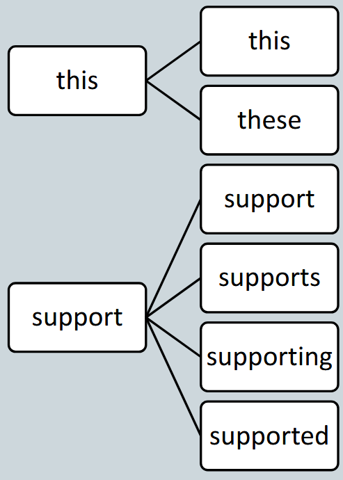

## Lemmatisation changes the representation

Live notebook **12** · Lemmatisation changes the representation

```python
for token in weather_doc:
    print(token.text, "=", token.lemma_)
```

```
This = this
morning = morning
there = there
were = be
clouds = cloud
in = in
the = the
sky = sky
. = .
However = however
, = ,
the = the
weather = weather
improved = improve
in = in
the = the
afternoon = afternoon
! = !
```

`token.lemma_` gives spaCy’s proposed base form as text. The loop displays each original token beside its lemma. These results were produced when we ran `nlp(weather_text)`; accessing them does not change the original sentence.

## Now with stopwords removed

**Combine the lemma and stopword information:**

Live notebook **13** · Now with stopwords removed

```python
lemmas = []
for token in weather_doc:
    if not token.is_stop and not token.is_punct:
        lemmas.append(token.lemma_)
print(lemmas)
```

```
['morning', 'cloud', 'sky', 'weather', 'improve', 'afternoon']
```

**Is there still meaning?**

I think many of us would struggle to decipher this.

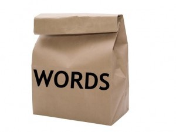

## A typical NLP pipeline: morphological tagging

1. Tokenisation
2. Pre-processing
3. Lemmatisation
4. Morphological tagging
5. Part-of-speech tagging
6. Syntactic parsing
7. Information extraction
8. Analysis

**Now: Morphological tagging.**

Not every step necessary. Choose the operations needed for the question. These are not compulsory steps.

## Morphological tagging

Morphological annotation describes grammatical features such as tense, number, gender, case, or degree. It records information beyond the surface form.

- `walked` → verb, past tense
- `dogs` → noun, plural
- `better` → adjective, comparative (in an appropriate sentence)

Inspect two forms in our actual weather sentence:

Live notebook **14** · Morphological tagging

```python
print(weather_doc[3].text, "is", weather_doc[3].morph)
print(weather_doc[4].text, "is", weather_doc[4].morph)
```

```
were is Mood=Ind|Tense=Past|VerbForm=Fin
clouds is Number=Plur
```

`morph` contains the pipeline’s *predicted* features - this comes from the model we loaded at the start.

## A typical NLP pipeline: part-of-speech tagging

1. Tokenisation
2. Pre-processing
3. Lemmatisation
4. Morphological tagging
5. Part-of-speech tagging
6. Syntactic parsing
7. Information extraction
8. Analysis

**Now: Part-of-speech tagging.**

Not every step necessary. Choose the operations needed for the question. These are not compulsory steps.

## Part-of-speech (POS) tagging

Assign a token its grammatical category according to its use in the sentence. The same form can have different functions. E.g., `run` in “a 5k run” and “I run daily”.

Live notebook **15** · Part-of-speech (POS) tagging

```python
noun_doc = nlp("I bought a book.")
verb_doc = nlp("I will book a ticket.")

print(noun_doc[3].text, noun_doc[3].pos_)
print(verb_doc[2].text, verb_doc[2].pos_)
```

```
book NOUN
book VERB
```

POS needs the sentence to construct context. It doesn’t assign an isolated word a permanent category.

## A typical NLP pipeline: syntactic parsing

1. Tokenisation
2. Pre-processing
3. Lemmatisation
4. Morphological tagging
5. Part-of-speech tagging
6. Syntactic parsing
7. Information extraction
8. Analysis

**Now: Syntactic parsing.**

Not every step necessary. Choose the operations needed for the question. These are not compulsory steps.

## Syntactic parsing

Analyse how words form phrases and relate grammatically: **who does what to whom**.

**Constituency:** nested phrases (the example on the right).

**Dependency:** relations between individual words.

In “The cat sat on the mat”:

- `cat` is the subject of `sat`
- `sat` is the main verb
- `on the mat` supplies a prepositional phrase

spaCy’s dependency parse supplies `token.dep_` and `token.head`.

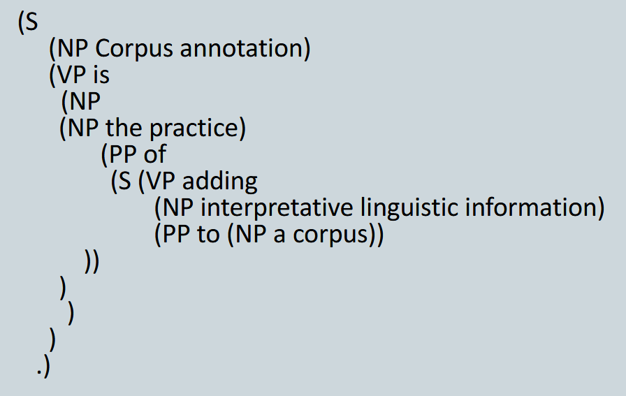

## A typical NLP pipeline: information extraction

1. Tokenisation
2. Pre-processing
3. Lemmatisation
4. Morphological tagging
5. Part-of-speech tagging
6. Syntactic parsing
7. Information extraction
8. Analysis

**Now: Information extraction.**

Not every step necessary. Choose the operations needed for the question. These are not compulsory steps.

## Typical extraction and text-analysis tasks

- Keyword identification and extraction
- Collocation analysis
- Sentiment analysis
- Topic modelling
- Named-entity recognition

These are different tasks with different inputs and assumptions. They do not all require every linguistic annotation.

Today: word frequencies across articles and categories, and sentiment in reviews. The worksheet includes practice with named entities. Next week: topic modelling.

## A typical NLP pipeline: analysis

1. Tokenisation
2. Pre-processing
3. Lemmatisation
4. Morphological tagging
5. Part-of-speech tagging
6. Syntactic parsing
7. Information extraction
8. Analysis

**Now: Analysis.**

Not every step necessary. Choose the operations needed for the question. These are not compulsory steps.

## Interpretation is key

**During analysis, ask:**

- These words are frequent - what does that mean in their source passages?
- How does the result change with preprocessing?
- How does it answer the research question?
- Is it expected or surprising?
- Does it reflect a particular genre, period or other property of this corpus?

Quantitative results need interpretation and supporting evidence. Explain every output included in a report.

# Part III: Counting words

**A small toolkit.** Load real text, tokenise it, and count — across the corpus, in one article, and by group.

## Technique 1 · Load the data

Load a table of texts from a file. Your own data loads the same way — a column of a CSV, or a text file.

Live notebook **16** · Load the data

```python
import pandas as pd
corpus = pd.read_csv(teaching_file("w09_corpus.csv.gz"))
display(corpus[["title", "category", "borough"]].head())
print("First article begins:", corpus["text"].iloc[0][:150])
# your own data loads the same way:
# corpus = pd.read_csv("my_reviews.csv")               # a CSV with a text column
# text   = open("my_notes.txt", encoding="utf-8").read()   # a single text file
```

|  | title | category | borough |
| --- | --- | --- | --- |
| 0 | 100 Club | Music venue | Westminster |
| 1 | 2 Willow Road | Museum | Camden |
| 2 | 606 Club | Music venue | Kensington and Chelsea |
| 3 | 7 Hammersmith Terrace | Museum | Hammersmith and Fulham |
| 4 | Adelphi Theatre | Theatre | Westminster |

```
First article begins: The 100 Club is a music venue located at 100 Oxford Street, Westminster, England, where it has been hosting live music since 24 October 1942. It was o
```

`read_csv` loads any CSV; swap the path for your own file. Each row here is one Wikipedia article, with its text, category and borough.

## Technique 2 · Tokenise each article

Repeat the tokenisation for every article. Keep each article’s tokens in a list.

Live notebook **17** · Tokenise each article

```python
article_tokens = []
for text in corpus["text"]:
    doc = nlp.tokenizer(text)
    article_tokens.append(list(doc))
corpus["token"] = article_tokens
display(corpus[["title", "token"]].head(2))
```

|  | title | token |
| --- | --- | --- |
| 0 | 100 Club | [The, 100, Club, is, a, music, venue, located,... |
| 1 | 2 Willow Road | [2, Willow, Road, is, part, of, a, terrace, of... |

`nlp.tokenizer(text)` splits one text into tokens. `list(doc)` puts its tokens in a list; `.append()` adds that list to `article_tokens`.

## Technique 2 · One row per token

Unpack the lists so we can count tokens in a familiar table.

Live notebook **18** · One row per token

```python
words = corpus.explode("token")
display(words[["title", "category", "token"]].head(6))
```

|  | title | category | token |
| --- | --- | --- | --- |
| 0 | 100 Club | Music venue | The |
| 0 | 100 Club | Music venue | 100 |
| 0 | 100 Club | Music venue | Club |
| 0 | 100 Club | Music venue | is |
| 0 | 100 Club | Music venue | a |
| 0 | 100 Club | Music venue | music |

`.explode("token")` turns each item in a token list into a separate row. The article’s title and category are repeated alongside each token.

## Technique 2 · Choose the words to count

Keep alphabetic tokens that are not stop words. Count lowercase word forms.

Live notebook **19** · Choose the words to count

```python
keep = []
word_text = []
for token in words["token"]:
    keep.append(token.is_alpha and not token.is_stop)
    word_text.append(token.lower_)
words["word"] = word_text
words = words[keep]
display(words[["title", "category", "word"]].head(6))
```

|  | title | category | word |
| --- | --- | --- | --- |
| 0 | 100 Club | Music venue | club |
| 0 | 100 Club | Music venue | music |
| 0 | 100 Club | Music venue | venue |
| 0 | 100 Club | Music venue | located |
| 0 | 100 Club | Music venue | oxford |
| 0 | 100 Club | Music venue | street |

`keep` collects a True/False decision for each row. `words[keep]` selects the True rows. `token.lower_` supplies the lowercase form, not a lemma.

## Technique 3 · Most frequent across the corpus

Count the word column with `value_counts` — the same verb as counting one text.

Live notebook **20** · Most frequent across the corpus

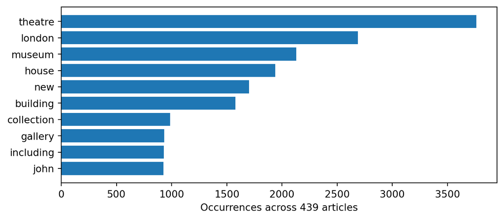

```python
import matplotlib.pyplot as plt
top = words["word"].value_counts().head(10).sort_values()
fig, ax = plt.subplots(figsize=(7, 3), layout="constrained")
ax.barh(top.index, top.values)
ax.set_xlabel("Occurrences across 439 articles")
plt.show()
```

`value_counts()` on the whole word column counts every word in the corpus.

## Technique 4 · Most frequent in one article

Filter the same table to one article.

Live notebook **21** · Most frequent in one article

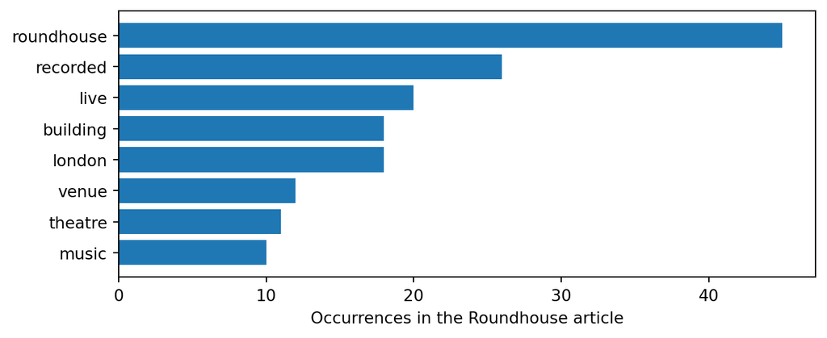

```python
one_article = words[words["title"] == "Roundhouse (venue)"]
top = one_article["word"].value_counts().head(8).sort_values()
fig, ax = plt.subplots(figsize=(7, 2.8), layout="constrained")
ax.barh(top.index, top.values)
ax.set_xlabel("Occurrences in the Roundhouse article")
plt.show()
```

Filter the word table to one article’s rows, then `value_counts`.

## Technique 5 · Most frequent by group

Count within museums, theatres and music venues, using the category column.

Live notebook **22** · Most frequent by group

```python
pd.DataFrame({
    category: words[words["category"] == category]["word"].value_counts().head(6).index
    for category in ["Museum", "Theatre", "Music venue"]})
```

|  | Museum | Theatre | Music venue |
| --- | --- | --- | --- |
| 0 | museum | theatre | london |
| 1 | house | starring | st |
| 2 | london | london | church |
| 3 | collection | new | stadium |
| 4 | gallery | directed | venue |
| 5 | building | building | new |

The category came in with the data, so we just filter and `value_counts` per group.

## Technique 6 · Top words as a proportion

Counts favour the biggest group. A **share** — `value_counts(normalize=True)` — lets us compare groups of different sizes.

Live notebook **23** · Top words as a proportion

```python
rows = []
for category in ["Museum", "Theatre", "Music venue"]:
    share = words[words["category"] == category]["word"].value_counts(normalize=True).head(4) * 100
    for word, percent in share.items():
        rows.append({"category": category, "word": word, "percent": round(percent, 2)})
pd.DataFrame(rows)
```

|  | category | word | percent |
| --- | --- | --- | --- |
| 0 | Museum | museum | 1.44 |
| 1 | Museum | house | 0.89 |
| 2 | Museum | london | 0.80 |
| 3 | Museum | collection | 0.66 |
| 4 | Theatre | theatre | 3.13 |
| 5 | Theatre | starring | 0.79 |
| 6 | Theatre | london | 0.73 |
| 7 | Theatre | new | 0.64 |
| 8 | Music venue | london | 1.08 |
| 9 | Music venue | st | 0.80 |
| 10 | Music venue | church | 0.75 |
| 11 | Music venue | stadium | 0.74 |

`normalize=True` turns counts into shares, so a bigger group no longer looks bigger.

# Part IV: Sentiment in reviews

**Switch source.** Wikipedia describes; reviews evaluate. We score every review, then check the scores against the visitors’ star ratings.

## Technique 7 · Score sentiment across the reviews

**VADER** scores each text from −1 (negative) to +1 (positive). Apply it to every review.

Live notebook **24** · Score sentiment

```python
from vaderSentiment.vaderSentiment import SentimentIntensityAnalyzer
scorer = SentimentIntensityAnalyzer()
reviews = pd.read_csv(teaching_file("w09_review_scores.csv"))
reviews["score"] = reviews["review_text"].apply(
    lambda text: scorer.polarity_scores(text)["compound"])
display(reviews[["canonical_name", "rating", "score"]].head(6))
```

|  | canonical_name | rating | score |
| --- | --- | --- | --- |
| 0 | Royal Academy of Arts | 1 | 0.2799 |
| 1 | Royal Academy of Arts | 1 | 0.7717 |
| 2 | Royal Academy of Arts | 1 | 0.8192 |
| 3 | Royal Academy of Arts | 5 | 0.9498 |
| 4 | Royal Academy of Arts | 5 | 0.8910 |
| 5 | Royal Academy of Arts | 5 | 0.4404 |

`.apply` runs the scorer on every review. We keep the original text — punctuation and capitals change the score.

## Technique 8 · Stars vs sentiment score

Do our scores agree with the visitors’ stars? Compare the mean score per star, and test the correlation.

Live notebook **25** · Stars vs sentiment

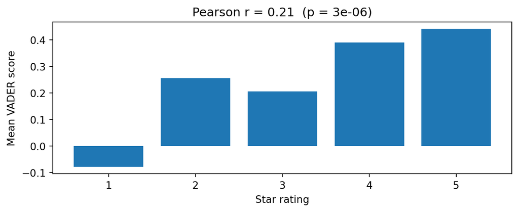

```python
from scipy.stats import pearsonr
mean_by_star = reviews.groupby("rating")["score"].mean()
r, p = pearsonr(reviews["rating"], reviews["score"])
fig, ax = plt.subplots(figsize=(7, 2.8), layout="constrained")
ax.bar(mean_by_star.index.astype(str), mean_by_star.values)
ax.set_xlabel("Star rating")
ax.set_ylabel("Mean VADER score")
ax.set_title(f"Pearson r = {r:.2f}  (p = {p:.1g})")
plt.show()
```

`pearsonr` returns the correlation and a p-value — a small p means the link is unlikely to be chance, not that it is strong.

# Part V: Contextual Analytics and text as evidence

1. **Use the chapter’s dimensions:** identify the context relevant to a claim.
2. **Plan the research:** connect the cultural object, evidence, representations, and checks.
3. **Apply this to text:** decide what our articles and reviews can tell us.

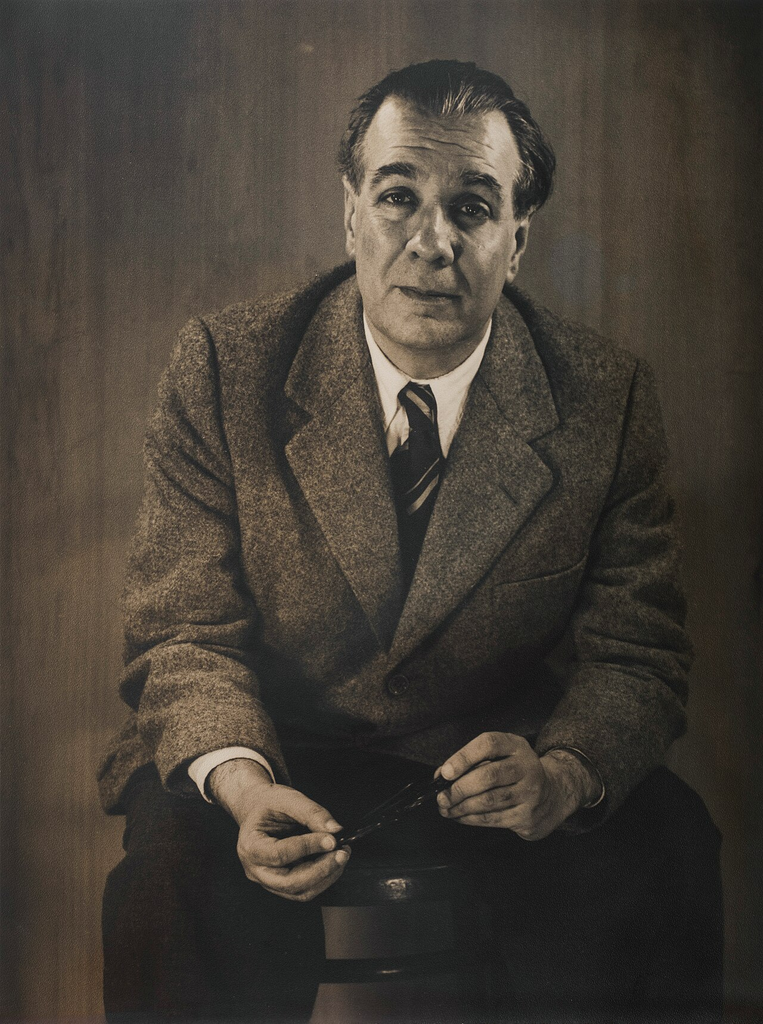

Jorge Luis Borges. Photo: Grete Stern, 1951.

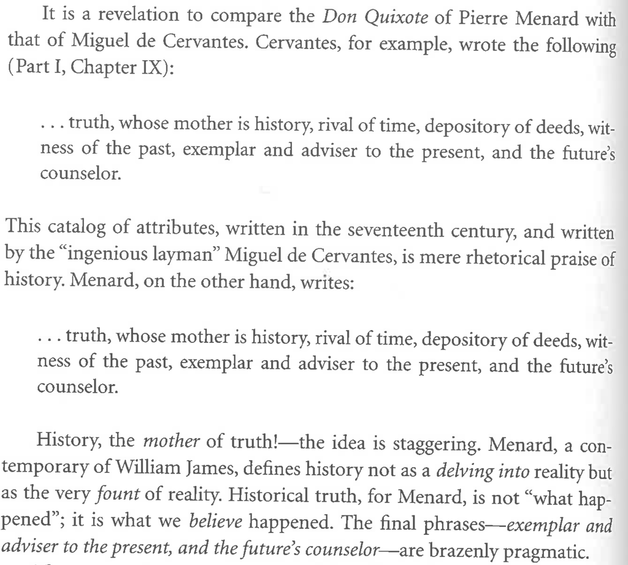

## Thin and thick description

> Consider […] two boys rapidly contracting the eyelids of their right eyes. In one, this is an involuntary twitch; in the other, a conspiratorial signal to a friend. The two movements are, as movements, identical; from an I-am-a-camera, “phenomenalistic” observation of them alone, one could not tell which was twitch and which was wink, or indeed whether both or either was twitch or wink. Yet the difference, however unphotographable, between a twitch and a wink is vast; as anyone unfortunate enough to have had the first taken for the second knows.

Clifford Geertz, “Thick Description” (1973), after Gilbert Ryle

**Thin** description records the movement. **Thick** description recovers what the movement *was*.

A measurement can be accurate about its object and still miss the cultural claim we make from it.

## Five dimensions and their computational units

The chapter’s **Table 1 (§3)** links each dimension to a computational unit and the analytical operations that unit makes possible.

| Dimension | Unit | Methods and operations |
| --- | --- | --- |
| **Semiotic** | Sign | Frequency, co-occurrence, similarity, classification |
| **Temporal** | Timestamp | Sequencing, periodisation, binning, rates of change |
| **Spatial** | Coordinate | Mapping, distance, clustering, centre–periphery, spatial autocorrelation |
| **Social** | Agent attribute | Grouping, comparison across populations, distributions |
| **Relational** | Edge | Centrality, paths, community detection, structural position |

These representations support different questions. Their **connections** make contextual analysis possible.

## How the dimensions interact

|  | Semiotic | Temporal | Spatial | Social | Relational |
| --- | --- | --- | --- | --- | --- |
| Semiotic | **Sign**: Recurring features and patterns (words, colours, sounds, etc.) | How features or styles change over time | How cultural features differ across places | How different groups produce or use different forms | How cultural elements are associated, linked, or combined |
| Temporal | — | **Timestamp**: Change, persistence, sequence, and recurrence | Where changes happen earlier or later | How groups, roles, or audiences change over time | How connections and circulation change over time |
| Spatial | — | — | **Coordinate**: Clustering, distance, concentration, and distribution | Where different groups, producers, or audiences are distributed | How connections and circulation vary across space |
| Social | — | — | — | **Attribute**: Grouping, classification, comparison | How social position relates to patterns of connection |
| Relational | — | — | — | — | **Edge**: connectivity, paths, centrality, clustering |

## A process for computational cultural research

**The argument of §5:** identify the dimensions a cultural claim depends on, and make their connections examinable within the research design.

| Research-design decision | What must be examined |
| --- | --- |
| **1. Cultural object and intended claim** | Distinguish the phenomenon from its surviving records. Identify the contextual evidence the intended claim requires. |
| **2. Dataset boundaries and their production** | Explain how recording, preservation and selection shape inclusion; how material becomes observations; and which context remains available. |
| **3. Representations and prior interpretation** | Establish what an encoding preserves or suppresses, and which assumptions about context are already built into categories, scores and ties. |
| **4. Plan how to analyse the dimensions together** | State which observations will be compared or connected, and how that analysis will examine the relationship your cultural claim proposes. |
| **5. Check whether the interpretation is supported** | Read the passages behind the pattern; repeat the analysis under a justified alternative selection or measure; examine further sources for evidence of the proposed explanation. |

The question is whether the evidence supports the move from a detected pattern to an interpretation of culture.

# Conclusion: Workshop and reporting

1. **Adapt the pattern:** build the token table with a different article.
2. **Support the interpretation:** counts and scores need passage evidence.
3. **Report the decisions:** explain how the analytical object was constructed.

## Report the decisions

- **Object and claim:** what are we studying, and what do we want to say?
- **Boundaries:** which sources, observations and contextual attributes enter?
- **Representations:** which forms, annotations, measures and denominators are used?
- **Interactions:** which comparison or connection supplies evidence for the claim?
- **Validation:** which cases and alternatives were checked; what remains uncertain?

## Workshop and next week

**Workshop:** create a spaCy Doc; inspect tokens and linguistic features; extract named entities; build pandas tables; compare London venue descriptions.

**Self-study:** loops and conditionals worksheet, with scaffolded tasks and self-check answers.

**Next week:** recurring themes across articles, then venue locations and distances.

## Sources and reproducibility

- Wikipedia contributors, [Roundhouse](https://en.wikipedia.org/w/index.php?oldid=1383110060), [Jazz Cafe](https://en.wikipedia.org/w/index.php?oldid=1379072447), [Horniman Museum](https://en.wikipedia.org/w/index.php?oldid=1364645747), CC BY-SA 4.0
- *Global Museum Visitor Reviews Dataset*, v2, [DOI 10.5281/zenodo.16752356](https://doi.org/10.5281/zenodo.16752356), CC BY 4.0
- Hill and Nulty, *Contextual Analytics*, §§3–5

Source identifiers, revisions, model settings and counting rules accompany the prepared lecture examples. Original text remains separate from derived measures.